# Análisis alzheimer

Carolina Mulet

2024-07-01

La proporción de valres faltantes del banco de datos es de 0.343985 .

# 1. Exploración

Tabla 1: Descriptivo numérico de las variables singulares.

|  | N | 0 (N=69) | 1 (N=64) | Total de pacientes (N=133) |
| --- | --- | --- | --- | --- |
| Genero | 133 |  |  |  |
| F |  | 41 (59.4%) | 34 (53.1%) | 75 (56.4%) |
| M |  | 28 (40.6%) | 30 (46.9%) | 58 (43.6%) |
| Edad | 133 |  |  |  |
| Mean (SD) |  | 63.9 (6.40) | 68.9 (5.84) | 66.3 (6.62) |
| Median [Q1, Q3] |  | 64.0 [61.0, 68.0] | 70.0 [66.0, 73.3] | 68.0 [62.0, 71.0] |

Tabla 2: Descriptivo numérico de los compuestos de peroxidación.

|  | N | 0 (N=69) | 1 (N=64) |
| --- | --- | --- | --- |
| 8-iso-15R-PGF2a | 42.5 |  |  |
| Mean (SD) |  | 0.539 (0.367) | 0.408 (0.295) |
| Median [Q1, Q3] |  | 0.500 [0.250, 0.675] | 0.363 [0.263, 0.531] |
| PGE2 | 42.5 |  |  |
| Mean (SD) |  | 0.442 (0.469) | 0.312 (0.466) |
| Median [Q1, Q3] |  | 0.325 [0.250, 0.450] | 0.0750 [0, 0.413] |
| 2,3-dinor-iPF2a | 42.5 |  |  |
| Mean (SD) |  | 0.0118 (0.0152) | 0.0141 (0.0219) |
| Median [Q1, Q3] |  | 0 [0, 0.0250] | 0 [0, 0.0250] |
| 8-iso-15-keto-PGE2 | 42.5 |  |  |
| Mean (SD) |  | 0.749 (0.712) | 0.345 (0.673) |
| Median [Q1, Q3] |  | 0.725 [0, 1.15] | 0 [0, 0.375] |
| 8-iso-15-keto-PGF2a | 42.5 |  |  |
| Mean (SD) |  | 0.625 (0.470) | 0.344 (0.395) |
| Median [Q1, Q3] |  | 0.500 [0.300, 0.825] | 0.275 [0.150, 0.381] |
| 8-iso-PGE2 | 42.5 |  |  |
| Mean (SD) |  | 2.07 (4.16) | 1.27 (1.53) |
| Median [Q1, Q3] |  | 1.00 [0.600, 1.58] | 0.688 [0.244, 1.98] |
| 5-iPF2a-VI | 42.5 |  |  |
| Mean (SD) |  | 2.38 (1.71) | 1.25 (1.52) |
| Median [Q1, Q3] |  | 2.13 [1.20, 2.98] | 1.05 [0.388, 1.43] |
| 8-iso-PGF2a | 42.5 |  |  |
| Mean (SD) |  | 0.0923 (0.146) | 0.0456 (0.122) |
| Median [Q1, Q3] |  | 0.0500 [0.0250, 0.0750] | 0.00850 [0, 0.0483] |
| PGF2a | 42.5 |  |  |
| Mean (SD) |  | 0.604 (0.553) | 0.484 (0.414) |
| Median [Q1, Q3] |  | 0.500 [0.275, 0.825] | 0.438 [0.206, 0.694] |
| VB559m1 | 42.5 |  |  |
| Mean (SD) |  | 3.21 (3.14) | 1.42 (1.58) |
| Median [Q1, Q3] |  | 3.00 [1.30, 4.05] | 1.18 [0.263, 1.51] |
| 1a1bdihomo | 42.5 |  |  |
| Mean (SD) |  | 2.58 (2.66) | 1.39 (3.48) |
| Median [Q1, Q3] |  | 2.73 [0, 4.08] | 0 [0, 0] |
| NeuroP tot | 42.5 |  |  |
| Mean (SD) |  | 0.392 (0.336) | 0.136 (0.259) |
| Median [Q1, Q3] |  | 0.391 [0, 0.648] | 0.00375 [0, 0.119] |
| AG495m4R | 42.5 |  |  |
| Mean (SD) |  | 0.194 (0.151) | 0.179 (0.166) |
| Median [Q1, Q3] |  | 0.175 [0.100, 0.275] | 0.163 [0.0188, 0.275] |
| CO1-31 | 42.5 |  |  |
| Mean (SD) |  | 1.40 (1.10) | 0.963 (0.896) |
| Median [Q1, Q3] |  | 1.30 [0.575, 1.90] | 0.888 [0, 1.77] |
| IsoP tot | 42.5 |  |  |
| Mean (SD) |  | 1.26 (0.706) | 0.570 (0.665) |
| Median [Q1, Q3] |  | 1.23 [0.730, 1.55] | 0.348 [0.274, 0.525] |
| CO5-769 | 42.5 |  |  |
| Mean (SD) |  | 0.192 (0.535) | 0.0898 (0.100) |
| Median [Q1, Q3] |  | 0 [0, 0.200] | 0.0500 [0, 0.150] |
| CO5-778 | 42.5 |  |  |
| Mean (SD) |  | 0.0198 (0.101) | 0.0289 (0.164) |
| Median [Q1, Q3] |  | 0 [0, 0] | 0 [0, 0] |
| CO5-776 | 42.5 |  |  |
| Mean (SD) |  | 0.0387 (0.117) | 0.0172 (0.0750) |
| Median [Q1, Q3] |  | 0 [0, 0] | 0 [0, 0] |
| ADT-207 | 42.5 |  |  |
| Mean (SD) |  | 0.0316 (0.164) | 0.00313 (0.0177) |
| Median [Q1, Q3] |  | 0 [0, 0] | 0 [0, 0] |
| ADT-420 | 42.5 |  |  |
| Mean (SD) |  | 0.144 (0.338) | 0.145 (0.317) |
| Median [Q1, Q3] |  | 0 [0, 0.225] | 0.0125 [0, 0.206] |
| NeuroF tot | 42.5 |  |  |
| Mean (SD) |  | 0.263 (0.165) | 0.262 (0.171) |
| Median [Q1, Q3] |  | 0.258 [0.128, 0.369] | 0.231 [0.145, 0.428] |
| IsoF tot | 42.5 |  |  |
| Mean (SD) |  | 0.460 (0.275) | 0.273 (0.329) |
| Median [Q1, Q3] |  | 0.420 [0.307, 0.567] | 0.162 [0.103, 0.275] |

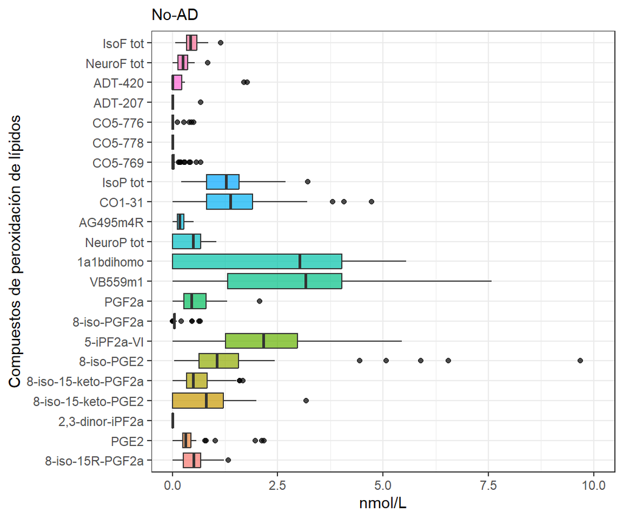

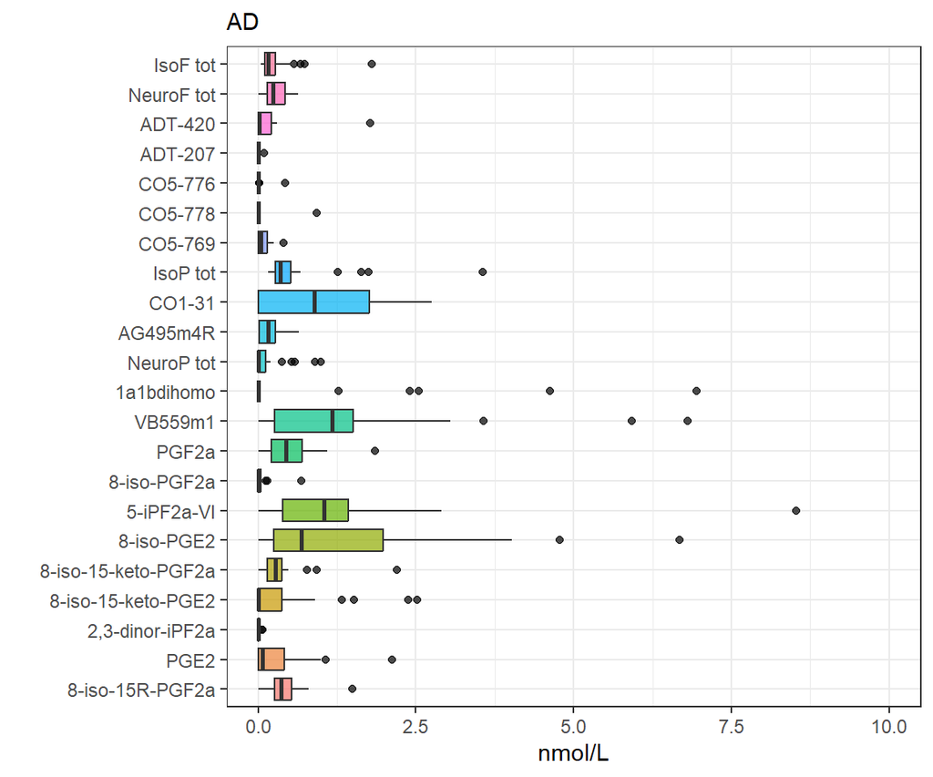

Figura 1: Diagrama de cajas de los compuestos de peroxidación de lípidos.

Tabla 3: Descriptivo numérico de los lípidos.

|  | N | 0 (N=69) | 1 (N=64) |
| --- | --- | --- | --- |
| 18:1 LPE | 60.5 |  |  |
| Mean (SD) |  | 1.74 (1.52) | 2.17 (1.80) |
| Median [Q1, Q3] |  | 1.45 [0.775, 1.85] | 1.78 [1.14, 2.64] |
| 18:0 LPC | 60.5 |  |  |
| Mean (SD) |  | 51.6 (31.2) | 50.5 (36.3) |
| Median [Q1, Q3] |  | 48.8 [23.7, 75.1] | 34.9 [22.8, 65.8] |
| 16:1 SM | 60.5 |  |  |
| Mean (SD) |  | 21.9 (13.2) | 22.6 (12.0) |
| Median [Q1, Q3] |  | 20.9 [13.2, 28.5] | 21.2 [15.1, 30.1] |
| 16:0 SM | 60.5 |  |  |
| Mean (SD) |  | 158 (55.1) | 157 (60.8) |
| Median [Q1, Q3] |  | 149 [116, 196] | 159 [108, 206] |
| DOPE | 60.5 |  |  |
| Mean (SD) |  | 9.41 (9.32) | 7.14 (7.54) |
| Median [Q1, Q3] |  | 7.33 [3.89, 11.8] | 3.87 [1.44, 11.5] |
| 18:0 SM | 60.5 |  |  |
| Mean (SD) |  | 87.6 (68.6) | 86.8 (60.3) |
| Median [Q1, Q3] |  | 69.4 [50.9, 101] | 74.6 [48.7, 105] |

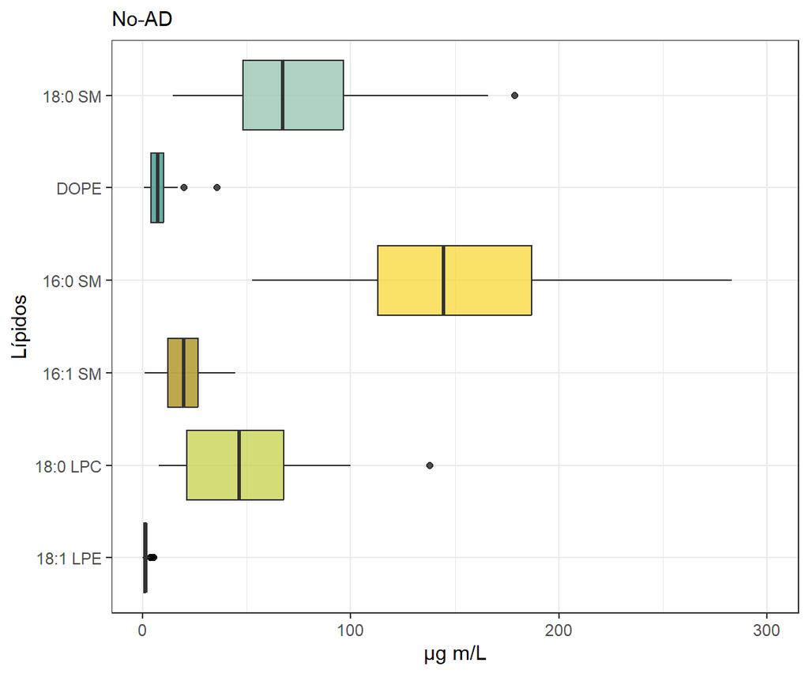

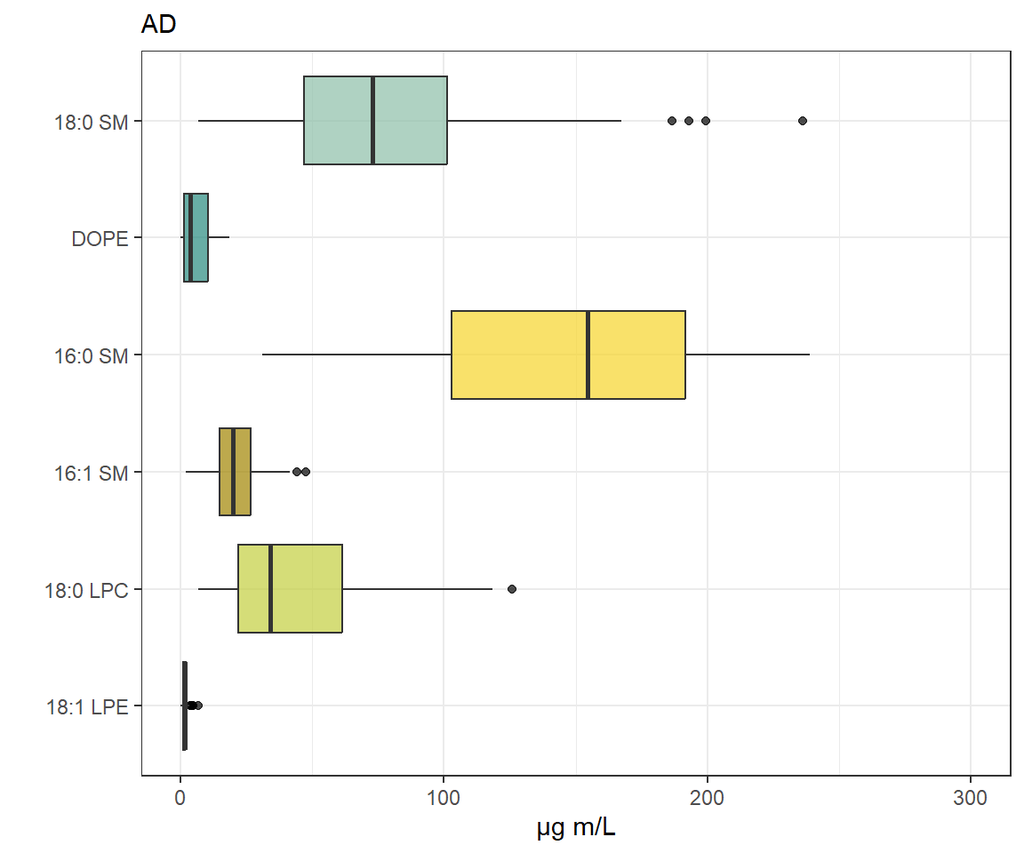

Figura 2: Diagrama de cajas de los lípidos.

Tabla 4: Descriptivo numérico de los MicroRNAs.

|  | N | 0 (N=69) | 1 (N=64) |
| --- | --- | --- | --- |
| miR-92a-3p | 23 |  |  |
| Mean (SD) |  | 1.31 (0.969) | 1.59 (1.57) |
| Median [Q1, Q3] |  | 0.833 [0.627, 1.92] | 1.28 [0.667, 1.62] |
| miR486-5p | 22.5 |  |  |
| Mean (SD) |  | 1.26 (0.990) | 1.24 (0.724) |
| Median [Q1, Q3] |  | 1.06 [0.661, 1.49] | 0.924 [0.702, 1.82] |
| miR-29a-3p | 22.5 |  |  |
| Mean (SD) |  | 1.34 (0.876) | 0.968 (0.497) |
| Median [Q1, Q3] |  | 1.07 [0.814, 2.12] | 0.879 [0.547, 1.25] |
| miR-486-3p | 21.5 |  |  |
| Mean (SD) |  | 1.23 (0.844) | 1.35 (0.852) |
| Median [Q1, Q3] |  | 0.988 [0.706, 1.92] | 1.33 [0.545, 2.12] |
| miR-150-5 | 23 |  |  |
| Mean (SD) |  | 1.69 (3.02) | 1.37 (0.957) |
| Median [Q1, Q3] |  | 0.988 [0.597, 1.26] | 1.28 [0.620, 1.82] |
| miR-320b | 22.5 |  |  |
| Mean (SD) |  | 1.25 (0.899) | 1.30 (0.694) |
| Median [Q1, Q3] |  | 0.914 [0.574, 1.65] | 1.14 [0.830, 1.66] |
| miR-483-3p | 23 |  |  |
| Mean (SD) |  | 1.13 (0.737) | 1.20 (0.711) |
| Median [Q1, Q3] |  | 0.983 [0.618, 1.36] | 1.06 [0.616, 1.59] |
| miR-342-3p | 23 |  |  |
| Mean (SD) |  | 1.39 (1.75) | 1.48 (1.12) |
| Median [Q1, Q3] |  | 0.920 [0.649, 1.13] | 1.21 [0.550, 2.39] |

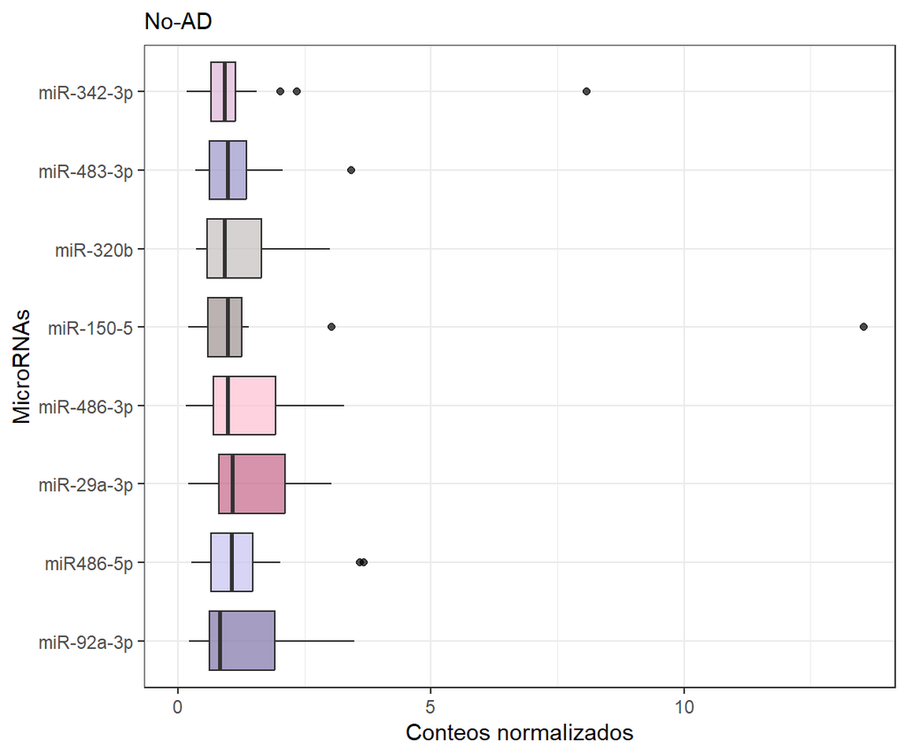

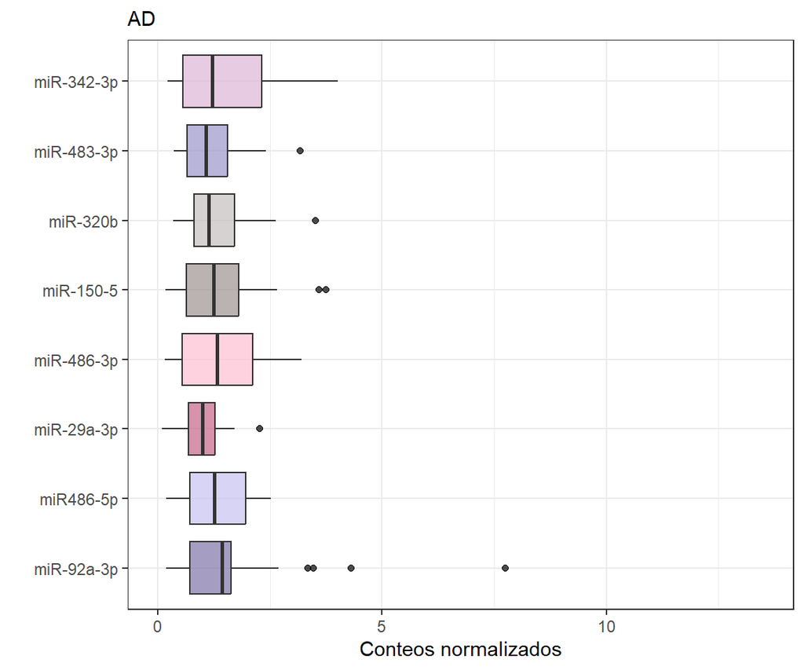

Diagrama de cajas de los MicroRNAs.

## 1.1 Tratamiento NAs

Con la librería mice. Se elige una de las bases de datos imputadas.

## 1.2 Estudio correlaciones

### Compuestos de peroxidación

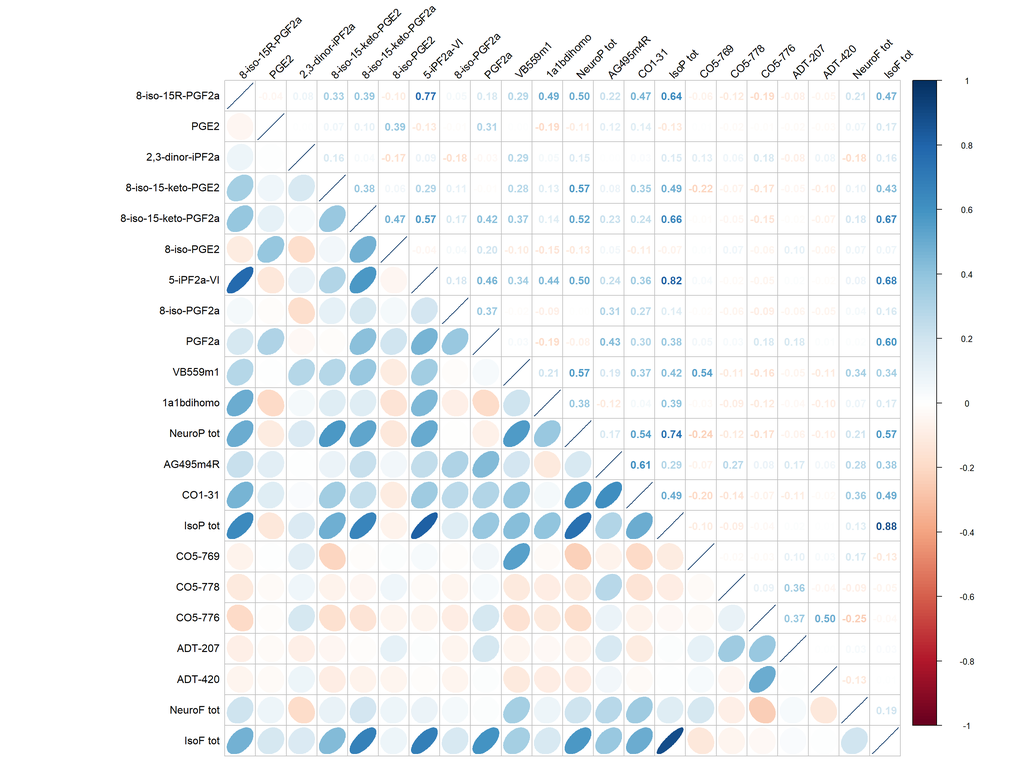

Figura 4: Representación gráfica de la matriz de correlación de los compuestos de peroxidación.

### Lípidos

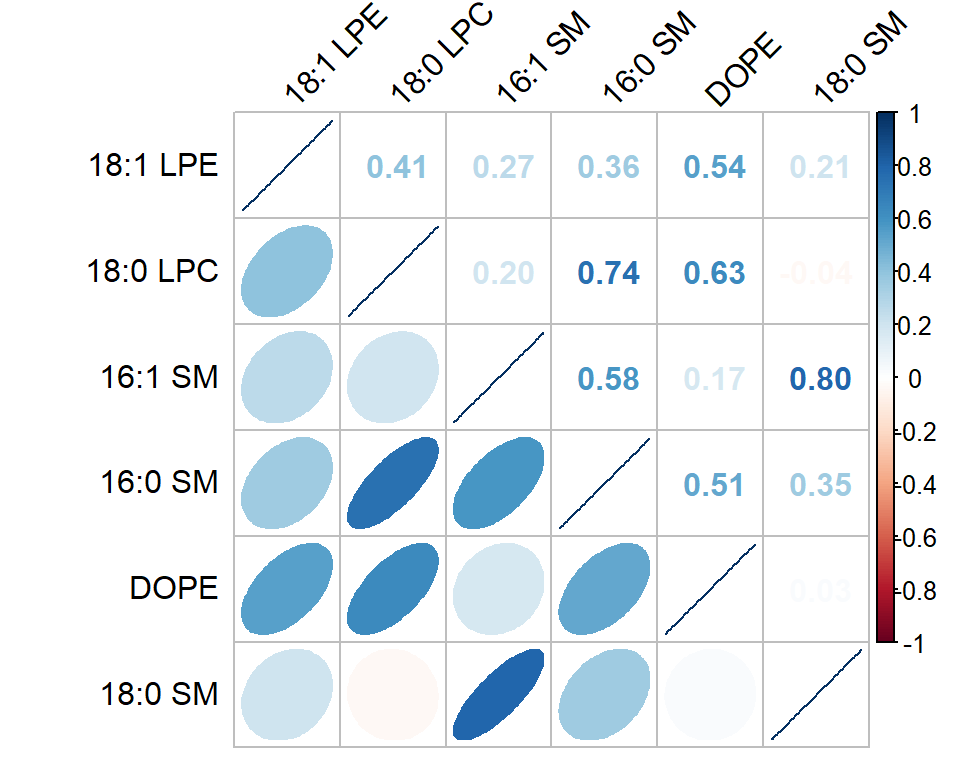

Figura 5: Representación gráfica de la matriz de correlación de los lípidos.

### MicroRNAs

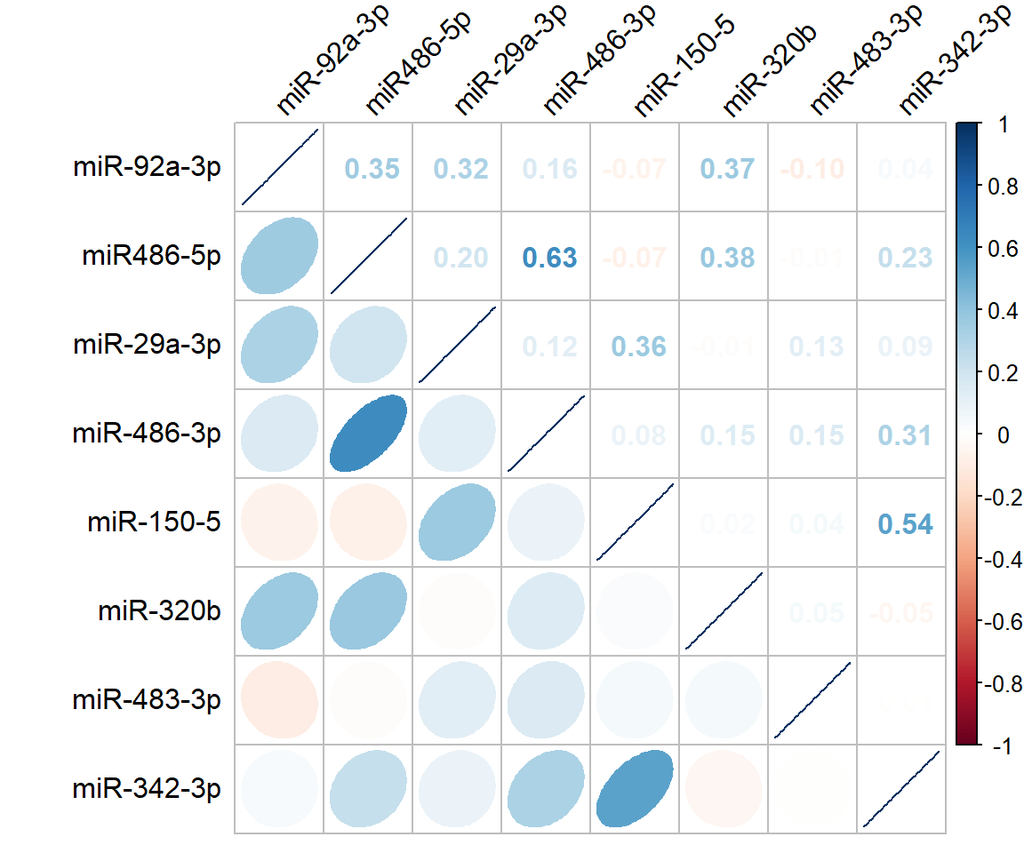

Figura 6: Representación gráfica de la matriz de correlación de los microRNAs.

# 2 Selección de variables bayesiana

## 2.1 Selección de variables con BAS

Probabilidades de inclusión a posteriori de las variables obtenidas con BAS.

|  | P(B != 0 &#124; Y) | model 1 | model 2 | model 3 |
| --- | --- | --- | --- | --- |
| Intercept | 1.0000000 | 1.0000000 | 1.00000 | 1.0000000 |
| `18_1_LysoPE` | 0.1352821 | 0.0000000 | 0.00000 | 0.0000000 |
| `18_0_LysoPC` | 0.0561513 | 0.0000000 | 0.00000 | 0.0000000 |
| `16_1_SM` | 0.0287445 | 0.0000000 | 0.00000 | 0.0000000 |
| `16_0_SM` | 0.0460727 | 0.0000000 | 0.00000 | 0.0000000 |
| DOPE | 0.0349901 | 0.0000000 | 0.00000 | 0.0000000 |
| `18_0_SM` | 0.0297612 | 0.0000000 | 0.00000 | 0.0000000 |
| `8-iso-15R-PGF2a` | 0.0420843 | 0.0000000 | 0.00000 | 0.0000000 |
| PGE2 | 0.0785638 | 0.0000000 | 0.00000 | 0.0000000 |
| `2,3-dinor-iPF2a` | 0.0330248 | 0.0000000 | 0.00000 | 0.0000000 |
| `8-iso-15-keto-PGE2` | 0.0952847 | 0.0000000 | 0.00000 | 0.0000000 |
| `8-iso-15-keto-PGF2a` | 0.1440394 | 0.0000000 | 0.00000 | 0.0000000 |
| `8-iso-PGE2` | 0.0907292 | 0.0000000 | 0.00000 | 0.0000000 |
| `5-iPF2a-VI` | 0.0643380 | 0.0000000 | 0.00000 | 0.0000000 |
| `8-iso-PGF2a` | 0.0272001 | 0.0000000 | 0.00000 | 0.0000000 |
| PGF2a | 0.0429001 | 0.0000000 | 0.00000 | 0.0000000 |
| VB559m1 | 0.0323497 | 0.0000000 | 0.00000 | 0.0000000 |
| `1a1bdihomo` | 0.0301683 | 0.0000000 | 0.00000 | 0.0000000 |
| `NeuroP tot` | 0.0753525 | 0.0000000 | 0.00000 | 0.0000000 |
| AG495m4R | 0.1149454 | 0.0000000 | 0.00000 | 0.0000000 |
| `CO1-31` | 0.0643166 | 0.0000000 | 0.00000 | 0.0000000 |
| `IsoP tot` | 0.6733909 | 1.0000000 | 1.00000 | 0.0000000 |
| `CO5-769` | 0.0292618 | 0.0000000 | 0.00000 | 0.0000000 |
| `CO5-778` | 0.0305441 | 0.0000000 | 0.00000 | 0.0000000 |
| `CO5-776` | 0.0332356 | 0.0000000 | 0.00000 | 0.0000000 |
| `ADT-207` | 0.0460277 | 0.0000000 | 0.00000 | 0.0000000 |
| `ADT-420` | 0.0259742 | 0.0000000 | 0.00000 | 0.0000000 |
| `NeuroF tot` | 0.0633669 | 0.0000000 | 0.00000 | 0.0000000 |
| `IsoF tot` | 0.0992001 | 0.0000000 | 0.00000 | 0.0000000 |
| `PCR1-miR-92a-3p4` | 0.0286586 | 0.0000000 | 0.00000 | 0.0000000 |
| `PCR2-miR486-5p5` | 0.0338477 | 0.0000000 | 0.00000 | 0.0000000 |
| `PCR3-miR-29a-3p6` | 0.5470055 | 0.0000000 | 1.00000 | 0.0000000 |
| `PCR4-miR-486-3p7` | 0.0323503 | 0.0000000 | 0.00000 | 0.0000000 |
| `PCR5-miR-150-5p8` | 0.0811849 | 0.0000000 | 0.00000 | 0.0000000 |
| `PCR8-miR-320b9` | 0.0546726 | 0.0000000 | 0.00000 | 0.0000000 |
| `PCR9-miR-483-3p10` | 0.0339266 | 0.0000000 | 0.00000 | 0.0000000 |
| `PCR11-miR-342-3p11` | 0.0488306 | 0.0000000 | 0.00000 | 0.0000000 |
| Edad | 0.9389398 | 1.0000000 | 1.00000 | 1.0000000 |
| GeneroM | 0.0256282 | 0.0000000 | 0.00000 | 0.0000000 |
| BF | NA | 0.1112441 | 1.00000 | 0.0020348 |
| PostProbs | NA | 0.0774000 | 0.05800 | 0.0262000 |
| R2 | NA | 0.1827000 | 0.22650 | 0.1160000 |
| dim | NA | 3.0000000 | 4.00000 | 2.0000000 |
| logmarg | NA | -81.0236011 | -78.82757 | -85.0249368 |

## 2.2 Selección de variables considerando la presencia de grupos

Probabilidades de inclusión de los grupos, variables agrupadas y singulares obtenidas con SB-SB.

Prob inclusión grupos y vars singulares

Prob inclusión vars agrupadas

peroxidation

0.985907933072144

Variables peroxidation:

`8-iso-15R-PGF2a`

0.97791742627457

PGE2

0.996641901024613

`2,3-dinor-iPF2a`

0.977615768421603

`8-iso-15-keto-PGE2`

0.980249065619628

`8-iso-15-keto-PGF2a`

0.981872105842701

`8-iso-PGE2`

0.967416968590847

`5-iPF2a-VI`

0.984961481398518

`8-iso-PGF2a`

0.979422538421233

PGF2a

0.996535409821308

VB559m1

0.968816679471854

`1a1bdihomo`

0.97268882299505

`NeuroP tot`

0.982428489343536

AG495m4R

0.988687766482798

`CO1-31`

0.995039937384933

`IsoP tot`

0.990683201979629

`CO5-769`

0.993389421128332

`CO5-778`

0.985660315260224

`CO5-776`

0.973459356191794

`ADT-207`

0.983484374251739

`ADT-420`

0.966782059008596

`NeuroF tot`

0.98170417411039

`IsoF tot`

0.991244123621901

lipids

0.979819473605302

Variables lipids:

`18_1_LysoPE`

0.999758776614986

`18_0_LysoPC`

0.987954943922523

`16_1_SM`

0.981884550285176

`16_0_SM`

0.971160537461469

DOPE

0.992043805201449

`18_0_SM`

0.984970252491446

microRNAs

0.985865055113605

Variables microRNAs:

`PCR1-miR-92a-3p4`

0.989583660318774

`PCR2-miR486-5p5`

0.96875437587984

`PCR3-miR-29a-3p6`

0.997571521247311

`PCR4-miR-486-3p7`

0.970604336415187

`PCR5-miR-150-5p8`

0.978131144248642

`PCR8-miR-320b9`

0.97320977143716

`PCR9-miR-483-3p10`

0.997161438760116

`PCR11-miR-342-3p11`

0.996368149182123

Variables singulares:

Edad

0.99999878363873

Genero

0.896215353762256

Probabilidades de inclusión de los grupos, variables agrupadas y singulares obtenidas con SB-Const.

Prob inclusión grupos y vars singulares

Prob inclusión vars agrupadas

peroxidation

1

Variables peroxidation:

`8-iso-15R-PGF2a`

0.463942683344978

PGE2

0.976489925884018

`2,3-dinor-iPF2a`

0.555087817108404

`8-iso-15-keto-PGE2`

0.380110984184792

`8-iso-15-keto-PGF2a`

0.317979731040403

`8-iso-PGE2`

0.303872201531255

`5-iPF2a-VI`

0.348958772307444

`8-iso-PGF2a`

0.299693739829392

PGF2a

0.811623666433783

VB559m1

0.460097867957651

`1a1bdihomo`

0.247003078437446

`NeuroP tot`

0.74767251036106

AG495m4R

0.847806637756493

`CO1-31`

0.68476368121151

`IsoP tot`

0.772964268383512

`CO5-769`

0.751523561201263

`CO5-778`

0.345940584266913

`CO5-776`

0.324591681524533

`ADT-207`

0.581078632076059

`ADT-420`

0.322030080862978

`NeuroF tot`

0.356204179671906

`IsoF tot`

0.721230544676504

lipids

0.753040632575156

Variables lipids:

`18_1_LysoPE`

0.965873372453721

`18_0_LysoPC`

0.702040295108549

`16_1_SM`

0.533133111576991

`16_0_SM`

0.499077404094868

DOPE

0.792750140685959

`18_0_SM`

0.584073880754722

microRNAs

0.914873482661112

Variables microRNAs:

`PCR1-miR-92a-3p4`

0.455205232523488

`PCR2-miR486-5p5`

0.462989465404042

`PCR3-miR-29a-3p6`

0.844290583005259

`PCR4-miR-486-3p7`

0.397304338196256

`PCR5-miR-150-5p8`

0.945805617521016

`PCR8-miR-320b9`

0.364188349892647

`PCR9-miR-483-3p10`

0.890858940321799

`PCR11-miR-342-3p11`

0.9696358716347

Variables singulares:

Edad

0.999981632726607

Genero

0.876545251557946

### Sin considerar la estructura de grupo: previa SB

Probabilidades de inclusión de los grupos, variables agrupadas y singulares obtenidas con SB.

Prob inclusión grupos y vars singulares

Prob inclusión vars agrupadas

peroxidation

0.999999999999998

Variables peroxidation:

`8-iso-15R-PGF2a`

0.98063033020996

PGE2

0.999998131521586

`2,3-dinor-iPF2a`

0.981173445390029

`8-iso-15-keto-PGE2`

0.979493531277485

`8-iso-15-keto-PGF2a`

0.979954041434374

`8-iso-PGE2`

0.975279508689852

`5-iPF2a-VI`

0.98609689186655

`8-iso-PGF2a`

0.976171733330995

PGF2a

0.999576791541907

VB559m1

0.973978445662106

`1a1bdihomo`

0.981045984852618

`NeuroP tot`

0.984566823554127

AG495m4R

0.990085410005994

`CO1-31`

0.99803948497073

`IsoP tot`

0.988932719939594

`CO5-769`

0.995664860656983

`CO5-778`

0.987018092693053

`CO5-776`

0.972674252452214

`ADT-207`

0.983040150860557

`ADT-420`

0.970724981451263

`NeuroF tot`

0.987717651964925

`IsoF tot`

0.993940164377929

lipids

0.999999999999998

Variables lipids:

`18_1_LysoPE`

0.999876657470962

`18_0_LysoPC`

0.989392298190248

`16_1_SM`

0.980753847943077

`16_0_SM`

0.972871768262011

DOPE

0.991886223439531

`18_0_SM`

0.984053929797695

microRNAs

0.999999999999998

Variables microRNAs:

`PCR1-miR-92a-3p4`

0.991464994159645

`PCR2-miR486-5p5`

0.973167907861586

`PCR3-miR-29a-3p6`

0.997082352914468

`PCR4-miR-486-3p7`

0.9749056287535

`PCR5-miR-150-5p8`

0.984181362355107

`PCR8-miR-320b9`

0.977558266855375

`PCR9-miR-483-3p10`

0.999970693481753

`PCR11-miR-342-3p11`

0.9927035248566

Variables singulares:

Edad

0.999999999999998

Genero

0.987315856886252

### Quitando NAs

Se han imputado muchos datos, veamos si con los datos originales eliminando los individuos con algún NA se obtiene lo mismo.

Probabilidades de inclusión de los grupos, variables agrupadas y singulares obtenidas con SB-SB.

Prob inclusión grupos y vars singulares

Prob inclusión vars agrupadas

peroxidation

1

Variables peroxidation:

`8-iso-15R-PGF2a`

0.989459246403681

PGE2

0.993206809256563

`2,3-dinor-iPF2a`

0.982840251263149

`8-iso-15-keto-PGE2`

0.977796190238087

`8-iso-15-keto-PGF2a`

0.979872717482732

`8-iso-PGE2`

0.988166004299525

`5-iPF2a-VI`

0.97388143452018

`8-iso-PGF2a`

0.989576745341255

PGF2a

0.976632352973235

VB559m1

0.975173432738462

`1a1bdihomo`

0.968603335734683

`NeuroP tot`

0.968897348869653

AG495m4R

0.98401132370156

`CO1-31`

0.983205421132385

`IsoP tot`

1

`CO5-769`

0.980581961108776

`CO5-778`

0.963563927395939

`CO5-776`

0.988924103862837

`ADT-207`

0.968875767412574

`ADT-420`

0.969726840260368

`NeuroF tot`

0.98671416690577

`IsoF tot`

0.997162529749222

lipids

0.417747600268044

Variables lipids:

`18_1_LysoPE`

0.999658263142459

`18_0_LysoPC`

0.993136111936142

`16_1_SM`

0.982740893110337

`16_0_SM`

0.978739319780934

DOPE

0.98193118725184

`18_0_SM`

0.98346809491602

Variables singulares:

Edad

0.579910658133757

Genero

0.580640604284819

Probabilidades de inclusión de los grupos, variables agrupadas y singulares obtenidas con SB-Const.

Prob inclusión grupos y vars singulares

Prob inclusión vars agrupadas

peroxidation

1

Variables peroxidation:

`8-iso-15R-PGF2a`

0.984799851006097

PGE2

0.97367003115381

`2,3-dinor-iPF2a`

0.488086113300944

`8-iso-15-keto-PGE2`

0.538207043166492

`8-iso-15-keto-PGF2a`

0.618377186717317

`8-iso-PGE2`

0.499397373188729

`5-iPF2a-VI`

0.556634057019563

`8-iso-PGF2a`

0.815035896391276

PGF2a

0.467774479826943

VB559m1

0.45803867509607

`1a1bdihomo`

0.683801845768496

`NeuroP tot`

0.37300457206109

AG495m4R

0.602342846981357

`CO1-31`

0.615404568569519

`IsoP tot`

1

`CO5-769`

0.954242153268945

`CO5-778`

0.414253059121585

`CO5-776`

0.777599687080931

`ADT-207`

0.275740596759567

`ADT-420`

0.497311740674657

`NeuroF tot`

0.891413602286448

`IsoF tot`

1

lipids

0.272685504533935

Variables lipids:

`18_1_LysoPE`

0.504967772362719

`18_0_LysoPC`

0.58077311009663

`16_1_SM`

0.483509061917917

`16_0_SM`

0.412342792462523

DOPE

0.39693402746201

`18_0_SM`

0.811908823697924

Variables singulares:

Edad

0.485824662276349

Genero

0.447469555586381

Prob inclusión vars agrupadas

peroxidation

0.999999999999998

Variables peroxidation:

`8-iso-15R-PGF2a`

0.98063033020996

PGE2

0.999998131521586

`2,3-dinor-iPF2a`

0.981173445390029

`8-iso-15-keto-PGE2`

0.979493531277485

`8-iso-15-keto-PGF2a`

0.979954041434374

`8-iso-PGE2`

0.975279508689852

`5-iPF2a-VI`

0.98609689186655

`8-iso-PGF2a`

0.976171733330995

PGF2a

0.999576791541907

VB559m1

0.973978445662106

`1a1bdihomo`

0.981045984852618

`NeuroP tot`

0.984566823554127

AG495m4R

0.990085410005994

`CO1-31`

0.99803948497073

`IsoP tot`

0.988932719939594

`CO5-769`

0.995664860656983

`CO5-778`

0.987018092693053

`CO5-776`

0.972674252452214

`ADT-207`

0.983040150860557

`ADT-420`

0.970724981451263

`NeuroF tot`

0.987717651964925

`IsoF tot`

0.993940164377929

lipids

0.999999999999998

Variables lipids:

`18_1_LysoPE`

0.999876657470962

`18_0_LysoPC`

0.989392298190248

`16_1_SM`

0.980753847943077

`16_0_SM`

0.972871768262011

DOPE

0.991886223439531

`18_0_SM`

0.984053929797695

microRNAs

0.999999999999998

Variables microRNAs:

`PCR1-miR-92a-3p4`

0.991464994159645

`PCR2-miR486-5p5`

0.973167907861586

`PCR3-miR-29a-3p6`

0.997082352914468

`PCR4-miR-486-3p7`

0.9749056287535

`PCR5-miR-150-5p8`

0.984181362355107

`PCR8-miR-320b9`

0.977558266855375

`PCR9-miR-483-3p10`

0.999970693481753

`PCR11-miR-342-3p11`

0.9927035248566

Variables singulares:

Edad

0.999999999999998

Genero

0.987315856886252